# Prediction of Correctness in performing Exercise

Arun Sathyanarayana

## Background

Using devices such as Jawbone Up, Nike FuelBand, and Fitbit, it is now possible to collect a large amount of data about personal activity relatively inexpensively. The goal of this project is to predict the manner in which participants perform an exercise. The data is sourced from http://groupware.les.inf.puc-rio.br/har wherein 6 participants were asked to perform the same set of exercises correctly and incorrectly with accelerometers placed on the belt, forearm, arm, and dumbell.

Below list is the approach followed in this project:

1. Preprocessing of Train data
2. Exploratory Analysis
3. Selection of Model
4. Predicting using Test data

## 1.Preprocessing of Train data

Load the training and testing set from the sources. Split the training set into training and test sets.

```r
library(caret)
trainURL <- "http://d396qusza40orc.cloudfront.net/predmachlearn/pml-training.csv"
testURL <- "http://d396qusza40orc.cloudfront.net/predmachlearn/pml-testing.csv"

training <- read.csv(url(trainURL))
testing <- read.csv(url(testURL))

label <- createDataPartition(training$classe, p = 0.7, list = FALSE)
train <- training[label, ]
test <- training[-label, ]
```

Some variables present in the dataset would not contribute for prediction like variables with NA values and constant values, thus removing such variables will make the computation simpler.

```r
NZV <- nearZeroVar(train)
train <- train[ ,-NZV]
test <- test[ ,-NZV]

label <- apply(train, 2, function(x) mean(is.na(x))) > 0.95
train <- train[, -which(label, label == FALSE)]
test <- test[, -which(label, label == FALSE)]

train <- train[ , -(1:5)]
test <- test[ , -(1:5)]
```

Now the number of variables has been reduced significantly.

## 2.Exploratory Analysis

Additionally number of variables can further be reduced by computing correlation between the existing variables.

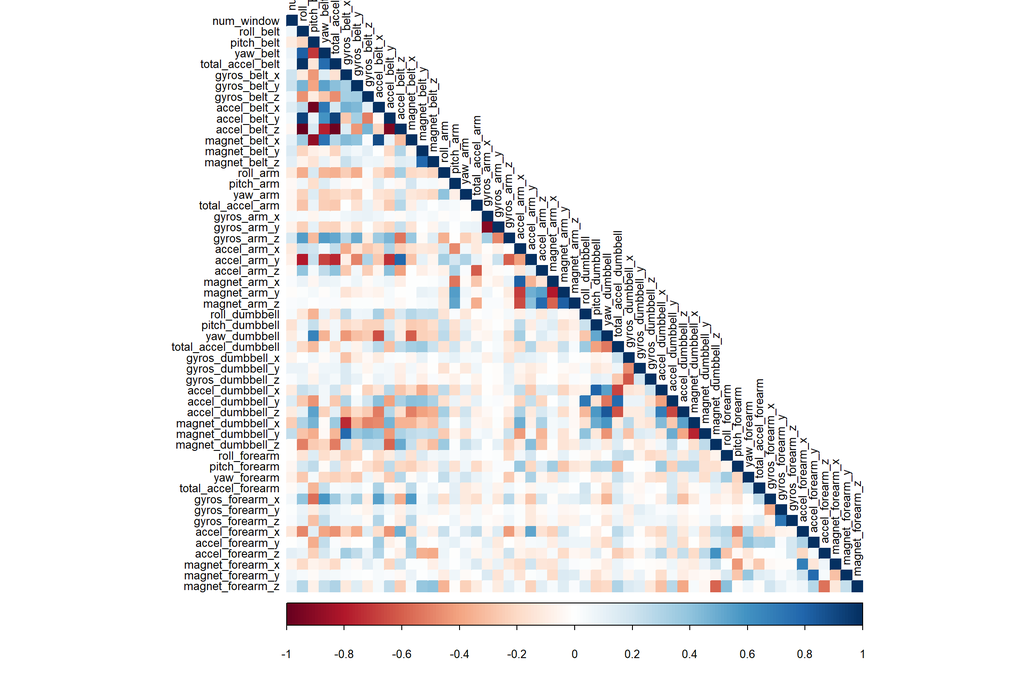

```r
library(corrplot)
corrMat <- cor(train[,-54])
corrplot(corrMat, method = "color", type = "lower", tl.cex = 0.8, tl.col = rgb(0,0,0))
```

From the plot it is clear that number of variabels with high correlations are less, so we shall proceed without dropping any of the variables.

## 3. Selection of Model

The methods used for modeling the data are Decision Tree, Random Forest and Generalized Boosted Model. Here confusion matrix is used for each model to understand the performance of it.

The one with with highest accuracy will be selected for prediction.

### 3.1 Decision Tree

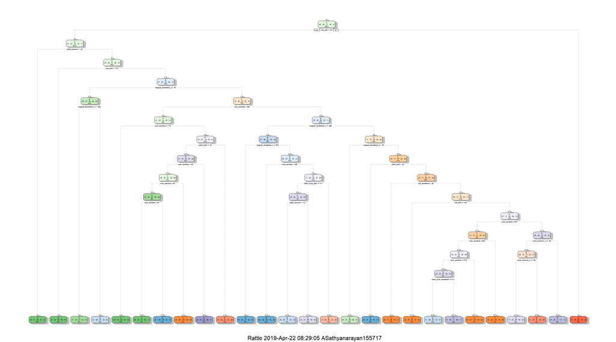

```r
library(rpart)
library(rpart.plot)
library(rattle)
set.seed(3433)
modelDT <- rpart(classe ~ ., data = train, method = "class")
fancyRpartPlot(modelDT)
```

```r
predictDT <- predict(modelDT, test, type = "class")
confMatDT <- confusionMatrix(predictDT, test$classe)
confMatDT
```

```
## Confusion Matrix and Statistics
##
##           Reference
## Prediction    A    B    C    D    E
##          A 1515  165   15   45   25
##          B   46  739   85   44   42
##          C    0   54  818   26    3
##          D   79  101   91  766   80
##          E   34   80   17   83  932
##
## Overall Statistics
##
##                Accuracy : 0.8105
##                  95% CI : (0.8003, 0.8205)
##     No Information Rate : 0.2845
##     P-Value [Acc > NIR] : < 2.2e-16
##
##                   Kappa : 0.7601
##
##  Mcnemar's Test P-Value : < 2.2e-16
##
## Statistics by Class:
##
##                      Class: A Class: B Class: C Class: D Class: E
## Sensitivity            0.9050   0.6488   0.7973   0.7946   0.8614
## Specificity            0.9406   0.9543   0.9829   0.9287   0.9554
## Pos Pred Value         0.8584   0.7730   0.9079   0.6858   0.8133
## Neg Pred Value         0.9614   0.9188   0.9583   0.9585   0.9683
## Prevalence             0.2845   0.1935   0.1743   0.1638   0.1839
## Detection Rate         0.2574   0.1256   0.1390   0.1302   0.1584
## Detection Prevalence   0.2999   0.1624   0.1531   0.1898   0.1947
## Balanced Accuracy      0.9228   0.8015   0.8901   0.8616   0.9084
```

### 3.2 Random Forest

```r
library(caret)
set.seed(3433)
control <- trainControl(method = "cv", number = 3, verboseIter=FALSE)
modelRF <- train(classe ~ ., data = train, method = "rf", trControl = control)
modelRF$finalModel
```

```
##
## Call:
##  randomForest(x = x, y = y, mtry = param$mtry)
##                Type of random forest: classification
##                      Number of trees: 500
## No. of variables tried at each split: 27
##
##         OOB estimate of  error rate: 0.23%
## Confusion matrix:
##      A    B    C    D    E class.error
## A 3906    0    0    0    0 0.000000000
## B   10 2645    3    0    0 0.004890895
## C    0    5 2391    0    0 0.002086811
## D    0    0    9 2243    0 0.003996448
## E    0    1    0    4 2520 0.001980198
```

```r
predictRF <- predict(modelRF, test)
confMatRF <- confusionMatrix(predictRF, test$classe)
confMatRF
```

```
## Confusion Matrix and Statistics
##
##           Reference
## Prediction    A    B    C    D    E
##          A 1673    2    0    0    0
##          B    0 1136    1    0    0
##          C    0    1 1025    0    0
##          D    0    0    0  963    2
##          E    1    0    0    1 1080
##
## Overall Statistics
##
##                Accuracy : 0.9986
##                  95% CI : (0.9973, 0.9994)
##     No Information Rate : 0.2845
##     P-Value [Acc > NIR] : < 2.2e-16
##
##                   Kappa : 0.9983
##
##  Mcnemar's Test P-Value : NA
##
## Statistics by Class:
##
##                      Class: A Class: B Class: C Class: D Class: E
## Sensitivity            0.9994   0.9974   0.9990   0.9990   0.9982
## Specificity            0.9995   0.9998   0.9998   0.9996   0.9996
## Pos Pred Value         0.9988   0.9991   0.9990   0.9979   0.9982
## Neg Pred Value         0.9998   0.9994   0.9998   0.9998   0.9996
## Prevalence             0.2845   0.1935   0.1743   0.1638   0.1839
## Detection Rate         0.2843   0.1930   0.1742   0.1636   0.1835
## Detection Prevalence   0.2846   0.1932   0.1743   0.1640   0.1839
## Balanced Accuracy      0.9995   0.9986   0.9994   0.9993   0.9989
```

### 3.3 Generalized Boosted Model

```r
library(caret)
set.seed(3433)
control <- trainControl(method = "repeatedcv", number = 5, repeats = 1, verboseIter = FALSE)
modelGBM <- train(classe ~ ., data = train, trControl = control, method = "gbm", verbose = FALSE)
modelGBM$finalModel
```

```
## A gradient boosted model with multinomial loss function.
## 150 iterations were performed.
## There were 53 predictors of which 53 had non-zero influence.
```

```r
predictGBM <- predict(modelGBM, test)
confMatGBM <- confusionMatrix(predictGBM, test$classe)
confMatGBM
```

```
## Confusion Matrix and Statistics
##
##           Reference
## Prediction    A    B    C    D    E
##          A 1669   13    0    2    0
##          B    4 1112    7    6    4
##          C    0   14 1016   12    2
##          D    1    0    3  942    6
##          E    0    0    0    2 1070
##
## Overall Statistics
##
##                Accuracy : 0.9871
##                  95% CI : (0.9839, 0.9898)
##     No Information Rate : 0.2845
##     P-Value [Acc > NIR] : < 2.2e-16
##
##                   Kappa : 0.9837
##
##  Mcnemar's Test P-Value : NA
##
## Statistics by Class:
##
##                      Class: A Class: B Class: C Class: D Class: E
## Sensitivity            0.9970   0.9763   0.9903   0.9772   0.9889
## Specificity            0.9964   0.9956   0.9942   0.9980   0.9996
## Pos Pred Value         0.9911   0.9815   0.9732   0.9895   0.9981
## Neg Pred Value         0.9988   0.9943   0.9979   0.9955   0.9975
## Prevalence             0.2845   0.1935   0.1743   0.1638   0.1839
## Detection Rate         0.2836   0.1890   0.1726   0.1601   0.1818
## Detection Prevalence   0.2862   0.1925   0.1774   0.1618   0.1822
## Balanced Accuracy      0.9967   0.9859   0.9922   0.9876   0.9942
```

Out of the three models, the Random Forest has highest accuracy and performs better for given data. Thus selecting the same for prediction.

## 4.Predicting using Test data

```r
predictRF <- predict(modelRF, testing)
predictRF
```

```
##  [1] B A B A A E D B A A B C B A E E A B B B
## Levels: A B C D E
```